# HW2 Solutions

1. (Select all that apply) Which of the following is true about this data:

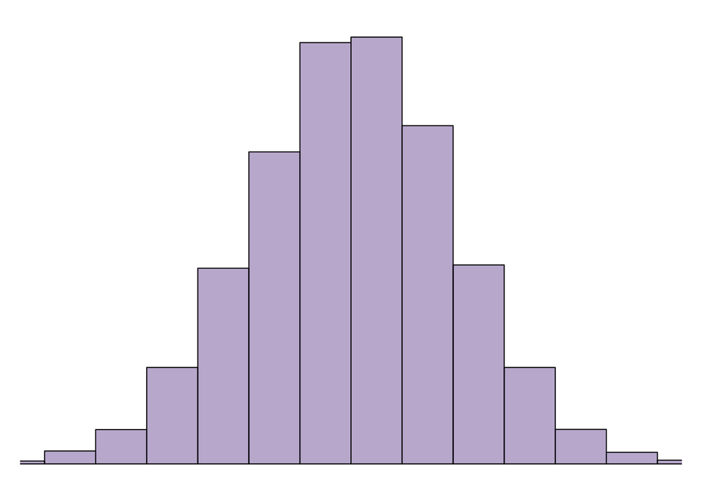

1. The median is less than the mean
2. There is more than one mode

**c. The median is equal to the mean**

**d. $95\%$ of the data is within $\mu \pm 2\sigma$**

5. The second quartile is approximately equal to the mode **Acceptable answer**
6. The median is greater than the mean
2. What percentage of observations in a distribution lie between the first and third quartile?
1. $25\%$

**b. $50\%$**

3. $75\%$
3. To make a boxplot of a distribution, you **must** know:
1. all the individual observations
2. the mean and the standard deviation

**c. the five-number summary**

4. What are all the values that a standard deviation $s$ can possibly take?

**a. $0 \le s$** (this should be $0 \le \infty$ but we’re here now)

2. $0 \le s \le 1$
3. $-1 \le s \le 1$
5. Which of the following is least affected if an extreme high outlier is added to your data?

**a. the median**

2. the mean
3. the standard deviation

> The previous homework described a study of female golden orb weaver spiders. The study also reported the body mass (in grams) for each of the $21$ spiders. Here are the data:

$$\begin{array}{|c|c|c|c|c|c|c|}
\hline
0.04 & 0.11 & 0.16 & 0.07 & 0.13 & 0.1 & 0.17\\
\hline
0.25 & 0.36 & 0.33 & 0.29 & 0.14 & 0.32 & 0.57\\
\hline
0.31 & 0.79 & 0.49 & 0.64 & 0.6 & 0.99 & 0.81\\
\hline
\end{array}$$

6. Give the five number summary and the mean for this data. How do the mean and the median compare?

$$\begin{array}{|c|c|c|c|c|}
\hline
\text{Min} & \text{Q}_1 & \text{Q}_2 & \text{Q}_3 &
\text{Max} \\
\hline
0.04 & 0.14 & 0.31 & 0.57 & 0.99 \\
\hline
\end{array}$$

$$\bar{x} = 0.365$$

7. Calculate the IQR. Are there any outliers in the data set?

$$\text{IQR} = \text{Q}_3 - \text{Q}_1 =
0.57 - 0.14 = 0.43$$

$$\text{Upper} = \text{Q}_3 +
1.5*\text{IQR} = 0.57 + (1.5*0.43) = 1.215$$

$$\text{Lower} = \text{Q}_1 -
1.5*\text{IQR} = 0.14 - (1.5*0.43) = -0.505$$

There are no outliers.

> In the early 1980s, Canadian gray wolves began colonizing the northwestern portion of Montana and by 1987, there were an estimated 10 gray wolves in Montana. With the increase in wolf numbers in the western U.S., there has been a corresponding increase in cattle and sheep depredation due to wolves. Below is tracking data from the years 1987-1991 regarding these wolf populations as well as wolf, cattle, and sheep depredation.

$$\begin{array}{|c|c|c|c|c|}
\hline
\text{Cattle Depredated} & \text{Sheep Depredated} &
\text{Wolves Killed} & \text{Wolf Population}\\
\hline
6 & 10 & 4 & 10\\
\hline
0 & 0 & 0 & 14\\
\hline
3 & 0 & 1 & 12\\
\hline
5 & 0 & 1 & 33\\
\hline
2 & 2 & 0 & 29\\
\hline
\end{array}$$

8. Make a time plot for the wolf population year over year (1987-1991). Draw a line across the plot for the mean wolf population.

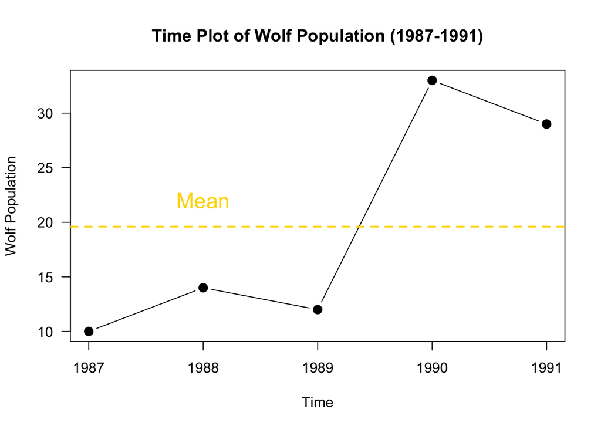

9. Make a scatterplot to observe the relationship between Cattle Depredated and Wolf Population. How would you describe this relationship?

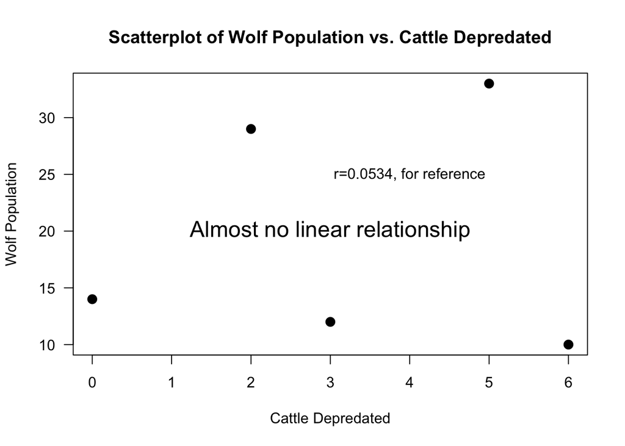

> Below are summary statistics and a boxplot for a study conducted on schizophrenic and non-schizophrenic individuals. Participants had their reaction times recorded over a series of tests.

> Schizophrenics

$$\begin{array}{|c|c|c|c|c|c|c|c|}
\hline
n & \bar x & \sum(x_i-\bar x)^2 & \text{Max} &
\text{Min} & \text{Q}_1 & \text{Q}_3 & \text{Median}\\
\hline
180 & 506.8667 & 12366881 & 1714 & 226 & 349 &
569 & 432\\
\hline
\end{array}$$

> Non-Schizophrenics

$$\begin{array}{|c|c|c|c|c|c|c|c|}
\hline
n & \bar x & \sum(x_i-\bar x)^2 & \text{Max} &
\text{Min} & \text{Q}_1 & \text{Q}_3 & \text{Median}\\
\hline
330 & 310.1697 & 1384918 & 778 & 204 & 266 & 344
& 303\\
\hline
\end{array}$$

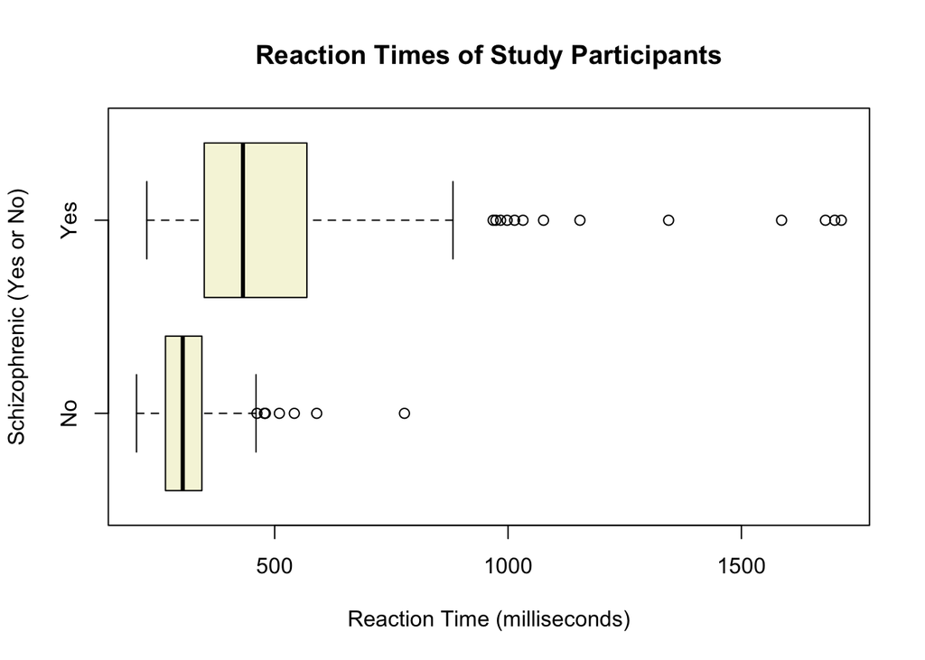

10. Calculate the range and standard deviation for both groups. How do they compare?

$$\begin{array}{|c|c|c|}
\hline
\text{Group} & \text{Range} & \sigma\\
\hline
\text{Yes} & 1488 & 262.8473\\
\hline
\text{No} & 574 & 64.8805\\
\hline
\end{array}$$

11. Plot the boxplot for the non-schizophrenics. What conclusions can be drawn from comparing your plot with the plot for the schizophrenics?

The densest region of data for the schizophrenic group is pushed further to the right relative to the non-schizophrenics. It could be said that the schizophrenic group has a higher average reaction time with higher variation between individuals.